# Win Prediction

OBJECTIVE:

In this project, I will be testing the ability to use game data such as Field Goal Percentage to predict whether a team is more likely to win.

KNN – Prediction Model Analysis

```r
#LOAD DATA AND LIBRARIES

#data set
games<-read.csv("games.csv", header=FALSE, stringsAsFactors = FALSE)

#libraries
library(class)
library(gmodels)
library(Amelia)
```

Step 2: We have to fix the data by removing unnecessary factors such as the date of the game, etc. We will also be removing the scores of the teams from the data since we will only be testing whether certain attributes affect win percentage.

```r
#FIX DATA

#set column names to the first row of data
colnames(games)<-games[1, ]

#get rid of unneeded columns
games$GAME_DATE_EST <- NULL
games$GAME_STATUS_TEXT <- NULL
games$HOME_TEAM_ID <-NULL
games$VISITOR_TEAM_ID <- NULL
games$SEASON <- NULL
games$TEAM_ID_home <- NULL
games$TEAM_ID_away <- NULL
games$GAME_ID <- NULL

games$PTS_away <- NULL
games$PTS_home <- NULL

#factor data based on whether home team wins
games$HOME_TEAM_WINS<-factor(games$HOME_TEAM_WINS,levels=c(0,1),labels=c("W","L"))
```

Here we will convert the data to the correct type, and get rid of any rows with NA vlues

```r
#convert data from character to numeric
games_data<-as.data.frame(apply(games[1:10],2,as.numeric))

#get rid of NA rows from target labels
games_target_labels<-games[complete.cases(games_data),11]

#get rid of NA from data
games_data = games_data[complete.cases(games_data), ]

g2 <- games_data
g2['HOME_TEAM_WINS'] <- games_target_labels
```

Here we will normalize the data, and test if there is missing data.

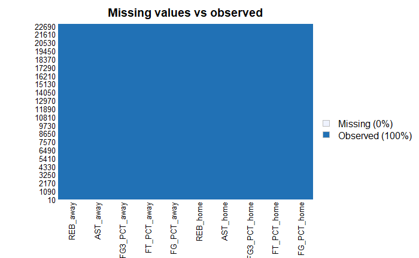

```r
#create normalization function
normalize<-function(x){
    return((x-min(x,na.rm=TRUE))/(max(x,na.rm=TRUE)-min(x,na.rm=TRUE)))
}

#normalize from game data
games_n<-as.data.frame(lapply(games_data[1:10],normalize))

#test if there is missing data
missmap(games_n, main = "Missing values vs observed")
```

Step 3: We will seperate the training data from the testing data

```r
#seperate training from testing data
games_train<-games_n[1:18400, ]
games_test<-games_n[18401:22945, ]

#seperate training from testing labels
games_train_labels<-games_target_labels[1:18400]
games_test_labels<-games_target_labels[18401:22945]
```

Step 4: We will run the Knn tests

After testing many values, I found that k=51 gave a good result.

```r
#RUN KNN TESTS
games_test_pred<-knn(train=games_train,test=games_test,cl=games_train_labels,k=51)

CrossTable(x=games_test_labels,y=games_test_pred,prop.chisq = FALSE)
```

```
   Cell Contents
|-------------------------|
|                       N |
|           N / Row Total |
|           N / Col Total |
|         N / Table Total |
|-------------------------|


Total Observations in Table:  4545


                  | games_test_pred
games_test_labels |         W |         L | Row Total |
------------------|-----------|-----------|-----------|
                W |      1470 |       431 |      1901 |
                  |     0.773 |     0.227 |     0.418 |
                  |     0.838 |     0.154 |           |
                  |     0.323 |     0.095 |           |
------------------|-----------|-----------|-----------|
                L |       284 |      2360 |      2644 |
                  |     0.107 |     0.893 |     0.582 |
                  |     0.162 |     0.846 |           |
                  |     0.062 |     0.519 |           |
------------------|-----------|-----------|-----------|
     Column Total |      1754 |      2791 |      4545 |
                  |     0.386 |     0.614 |           |
------------------|-----------|-----------|-----------|
```

This shows that it predicts correctly about 84% of the time.

We will attempt to imporve the performance of the knn model by using z-score

```r
#improving knn model performance
#z-score

games_z<-as.data.frame(scale(games_data[1:10]))
#summary(games_z)

z_train<-games_z[1:18400, ]
z_test<-games_z[18401:22945, ]

#seperate training from testing labels
z_train_labels<-games_target_labels[1:18400]
z_test_labels<-games_target_labels[18401:22945]

z_test_pred<-knn(train=z_train,test=z_test,cl=z_train_labels,k=51)

CrossTable(x=z_test_labels,y=z_test_pred,prop.chisq = FALSE)
```

```
   Cell Contents
|-------------------------|
|                       N |
|           N / Row Total |
|           N / Col Total |
|         N / Table Total |
|-------------------------|


Total Observations in Table:  4545


              | z_test_pred
z_test_labels |         W |         L | Row Total |
--------------|-----------|-----------|-----------|
            W |      1455 |       446 |      1901 |
              |     0.765 |     0.235 |     0.418 |
              |     0.841 |     0.158 |           |
              |     0.320 |     0.098 |           |
--------------|-----------|-----------|-----------|
            L |       276 |      2368 |      2644 |
              |     0.104 |     0.896 |     0.582 |
              |     0.159 |     0.842 |           |
              |     0.061 |     0.521 |           |
--------------|-----------|-----------|-----------|
 Column Total |      1731 |      2814 |      4545 |
              |     0.381 |     0.619 |           |
--------------|-----------|-----------|-----------|
```

Using z-score didn’t improve the model.

So we will try another k value

```r
z_test_pred<-knn(train=z_train,test=z_test,cl=z_train_labels,k=300)

CrossTable(x=z_test_labels,y=z_test_pred,prop.chisq = FALSE)
```

```
   Cell Contents
|-------------------------|
|                       N |
|           N / Row Total |
|           N / Col Total |
|         N / Table Total |
|-------------------------|


Total Observations in Table:  4545


              | z_test_pred
z_test_labels |         W |         L | Row Total |
--------------|-----------|-----------|-----------|
            W |      1425 |       476 |      1901 |
              |     0.750 |     0.250 |     0.418 |
              |     0.850 |     0.166 |           |
              |     0.314 |     0.105 |           |
--------------|-----------|-----------|-----------|
            L |       251 |      2393 |      2644 |
              |     0.095 |     0.905 |     0.582 |
              |     0.150 |     0.834 |           |
              |     0.055 |     0.527 |           |
--------------|-----------|-----------|-----------|
 Column Total |      1676 |      2869 |      4545 |
              |     0.369 |     0.631 |           |
--------------|-----------|-----------|-----------|
```